# Report on the Effects of Different Drug and Genetic Treatment on Training and Memory of Mice

Kyte Daiter Percia

2024-12-12

## Introduction

This report examines the effect of different genetic and drug treatments on training and memory of mice that are used in an experiment for prevention of Alzheimer’s disease. Training and Memory was measured on a continuous scale ranging from 0 to 20, with higher scores indicating greater performance. AD_Status (“Transgenic” and “Wild Type”) and Treatment (Drug 1-4) were used as an independent variables to determine their effects on training and memory. This will explore the interaction between the various genetic and drug treatmentto understand how these scientific processes are factors for the cure of Alzheimer’s disease through training and memory variables.

## Introduction

This report examines the effect of different genetic statuses and drug treatments on the training and memory performance of mice in an experiment testing potential Alzheimer’s disease prevention drugs. The performance in the maze task, measured by the number of errors made, was assessed on two days: the **Training Day** and the **Memory Day**. The scores range from 0 to 20, with higher scores indicating better performance. Two independent variables were used: **AD_Status** (Transgenic and Wild Type) and **Treatment** (Drugs 1-4). This report also explores the interaction between these factors to understand how they influence training and memory performance in the context of Alzheimer’s disease research.

## Method

### Participants

The sample consisted of 40 mice, categorized by genetic status and drug treatment: - **AD_Status**: - Transgenic (coded as 1) - Wild Type (coded as 2)

- **Treatment**:
  - Drug 1 (coded as 1)
  - Drug 2 (coded as 2)
  - Drug 3 (coded as 3)
  - Drug 4 (coded as 4)

Each mouse was assigned to a specific treatment group and tested on both the Training Day and the Memory Day.

The dependent variable, **memory performance**, was measured by the number of errors made by each mouse during the maze task, recorded for both the Training Day and the Memory Day.

### Procedure

The mice were administered one of the four drugs and tested in a maze task over two days: - **Training Day**: Mice are familiarized with the maze, and their performance (measured by errors) is recorded. - **Memory Day**: After a certain period, the mice are tested again to assess their memory retention, and errors are recorded.

The data was analyzed using a **Two-Way (2B) ANOVA** with two between-subject factors: **AD_Status** and **Treatment**. This statistical method was chosen to assess the main effects of both factors and their interaction on memory performance. The two dependent variables (Training Day and Memory Day scores) are continuous and measured on a scale from 0 to 20.

### Assumptions

*Assumption 1.* The dependent variable (training and memory performance) is measured at the continuous level (number of errors in the maze task).

*Assumption 2.* The two independent variables (AD_Status and Treatment) consist of two or more categorical independent groups. AD_Status is a dichotomous variable (Transgenic vs. Wild Type), while Treatment is a polytomous variable (Drugs 1-4).

*Assumption 3.* The independence of observations is assumed, meaning each mouse’s performance is independent of others.

*Assumption 4.* There should be no significant outliers in any cell of the design (i.e., no extreme values that unduly influence the results).

*Assumption 5.* The distribution of the dependent variable (residuals) should be approximately normally distributed in every cell of the design.

*Assumption 6.* The variance of the dependent variable (residuals) should be equal in every cell of the design (homoscedasticity).

## Hypothesis

**1. Main Effect of AD_Status**

*Training*

Null Hypothesis (H₀): There is no significant effect of AD_Status (Transgenic vs. Wild Type) on training performance (measured by the number of errors made).  
Alternative Hypothesis (H₁): There is a significant effect of AD_Status on training performance.

*Memory*

Null Hypothesis (H₀): There is no significant effect of AD_Status (Transgenic vs. Wild Type) on memory performance (measured by the number of errors made).  
Alternative Hypothesis (H₁): There is a significant effect of AD_Status on memory performance.

**2. Main Effect of Treatment**

*Training*

Null Hypothesis (H₀): There is no significant effect of Treatment (Drugs 1-4) on training performance.  
Alternative Hypothesis (H₁): There is a significant effect of Treatment on training performance.

*Memory*

Null Hypothesis (H₀): There is no significant effect of Treatment (Drugs 1-4) on memory performance.  
Alternative Hypothesis (H₁): There is a significant effect of Treatment on memory performance.

**3. Interaction Effect between AD_Status and Treatment**

*Training*

Null Hypothesis (H₀): There is no significant interaction effect between AD_Status and Treatment on training performance.  
Alternative Hypothesis (H₁): There is a significant interaction effect between AD_Status and Treatment on training performance.

*Memory*

Null Hypothesis (H₀): There is no significant interaction effect between AD_Status and Treatment on memory performance.  
Alternative Hypothesis (H₁): There is a significant interaction effect between AD_Status and Treatment on memory performance.

## Desriptive Analysis

```r
head(data)
```

```
##   AD_Status Treatment Training Memory
## 1         1         1       12     10
## 2         1         1       15     12
## 3         1         1       13     13
## 4         1         1       12     10
## 5         1         1       14     13
## 6         1         2       15     13
```

```r
summary(data)
```

```
##  AD_Status Treatment    Training         Memory
##  1:20      1:10      Min.   :12.00   Min.   : 4.000
##  2:20      2:10      1st Qu.:13.75   1st Qu.: 8.000
##            3:10      Median :14.00   Median :10.000
##            4:10      Mean   :14.72   Mean   : 9.925
##                      3rd Qu.:16.00   3rd Qu.:12.000
##                      Max.   :18.00   Max.   :15.000
```

```r
standard_dev_T <- sd(data$Training, na.rm = TRUE)
standard_dev_M <- sd(data$Memory, na.rm = TRUE)

print(sprintf("St. dev. of Traning: %.2f", standard_dev_T))
```

```
## [1] "St. dev. of Traning: 1.75"
```

```r
print(sprintf("St. dev. of Memory: %.2f", standard_dev_M))
```

```
## [1] "St. dev. of Memory: 2.74"
```

From the summary of descriptive statistics above, the data included 40 mice, with both 20 as as Transgenic and Wild Type. The distributions across Drug Treatments are equal as well, having 10 each for each of the four (4) Drug Types.

The dependent variables among the participants, even though were measured on a continuous scale, indicates a slightly high level of training performance, with scores ranging from 12 to 18 (*M* = 14.72, *SD* = 1.75), and slightly low level of memory performance, with scores ranging from 4 to 15 (*M* = 9.923, *SD* = 2.74).

*Assumption 1 and 2 was achieved*

```r
aggregate(Training ~ AD_Status + Treatment, data = data, FUN = base::mean)
```

```
##   AD_Status Treatment Training
## 1         1         1     13.2
## 2         2         1     15.4
## 3         1         2     15.8
## 4         2         2     15.8
## 5         1         3     15.2
## 6         2         3     15.2
## 7         1         4     13.6
## 8         2         4     13.6
```

```r
aggregate(Memory ~ AD_Status + Treatment, data = data, FUN = base::mean)
```

```
##   AD_Status Treatment Memory
## 1         1         1   11.6
## 2         2         1    8.6
## 3         1         2   13.2
## 4         2         2    7.6
## 5         1         3   12.4
## 6         2         3    8.2
## 7         1         4   11.2
## 8         2         4    6.6
```

The table indicates that both training and memory performance varies across combinations of genetic and drug treatments. Both Transgenic and Wild Type genetics with Type 2 Drug treatment reported the highest mean on training performance (*M* = 15.8), and only Transgenic genetic with also Type 2 Drug treatment on memory performance (*M* = 13.2). On the other hand, transgenic with Type 1 Drug Treatment reported the lowest mean on training performance (*M* = 13.2), and Wild Type with Type 4 Drug Treatment on memory performance (*M* = 6.6).

*Assumption 3 was achieved*

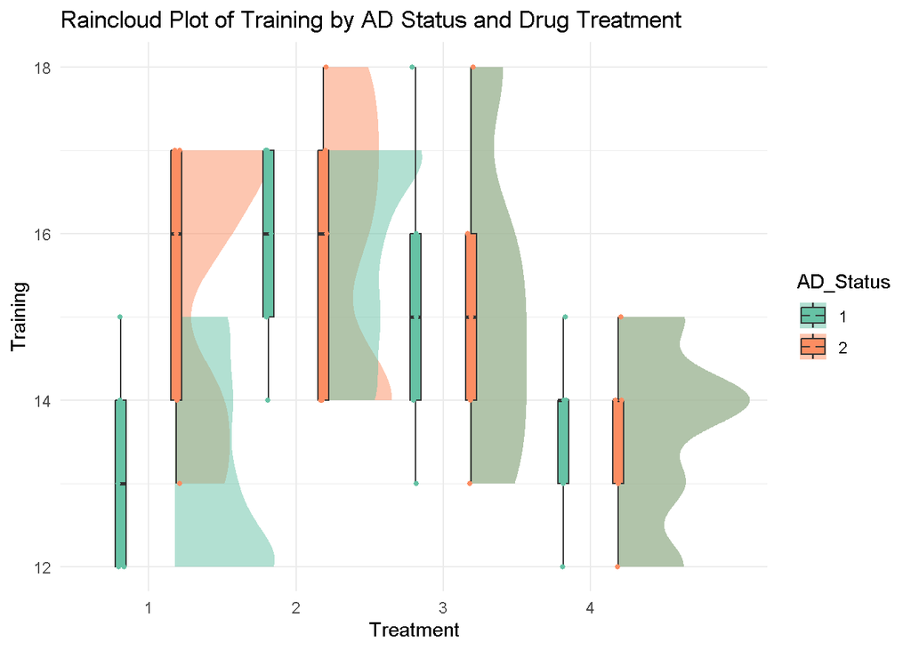

```r
ggplot(data, aes(x = Treatment, y = Training, fill = AD_Status)) +
  stat_halfeye(adjust = 0.5, justification = -0.2, .width = 0, point_colour = NA, alpha = 0.5) +
  geom_boxplot(width = 0.15, outlier.shape = NA, position = position_dodge(width = 0.75)) +
  geom_jitter(aes(color = AD_Status), position = position_jitterdodge(jitter.width = 0.1, dodge.width = 0.75), size = 1) +
  labs(x = "Treatment", y = "Training", title = "Raincloud Plot of Training by AD Status and Drug Treatment") +
  theme_minimal() +
  scale_fill_brewer(palette = "Set2") +
  scale_color_brewer(palette = "Set2")
```

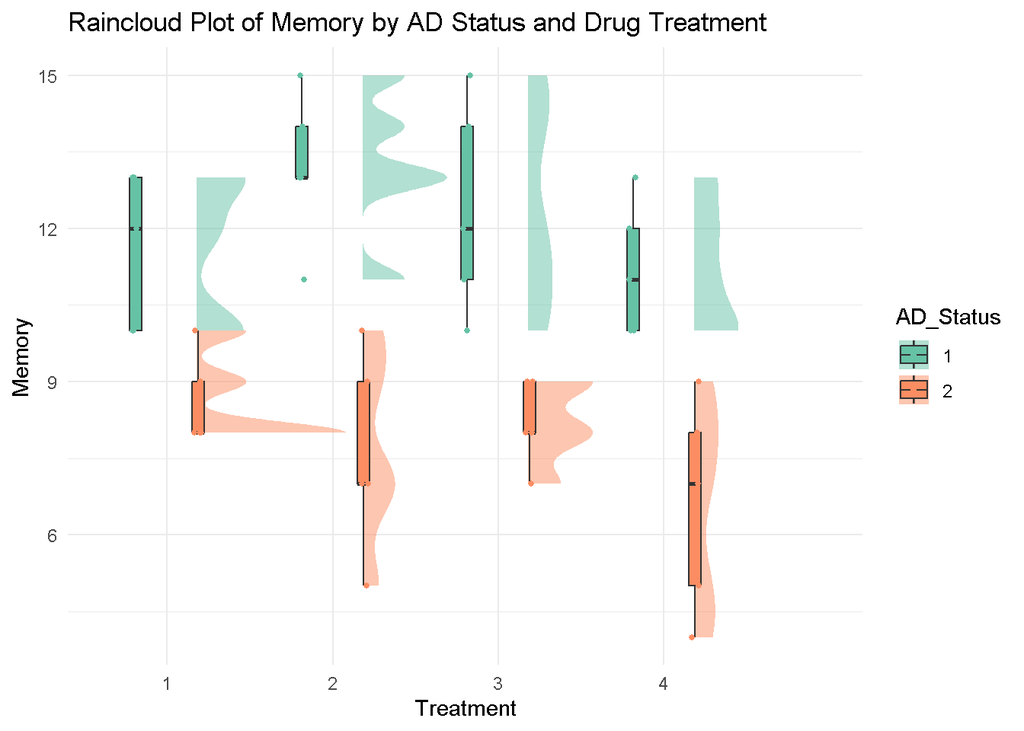

```r
ggplot(data, aes(x = Treatment, y = Memory, fill = AD_Status)) +
  stat_halfeye(adjust = 0.5, justification = -0.2, .width = 0, point_colour = NA, alpha = 0.5) +
  geom_boxplot(width = 0.15, outlier.shape = NA, position = position_dodge(width = 0.75)) +
  geom_jitter(aes(color = AD_Status), position = position_jitterdodge(jitter.width = 0.1, dodge.width = 0.75), size = 1) +
  labs(x = "Treatment", y = "Memory", title = "Raincloud Plot of Memory by AD Status and Drug Treatment") +
  theme_minimal() +
  scale_fill_brewer(palette = "Set2") +
  scale_color_brewer(palette = "Set2")
```

Both figure above visualize the distribution of **training** and **memory performance scores** across different **drug treatments**, separated by **genetic treatments**. The two figures show no significant outliers in the plot.

It can be seen that both genetic treatment almost have the same spread of scores on training performance on all drug treatments except Type 1. While on the memory performance, the distribution of scores are consistent througout all drug treatments, having transgenic scoring better.

*Assumption 4 was achieved*

```r
model_T <- aov(Training ~ AD_Status * Treatment, data=data)

shapiro.test(residuals(model_T))
```

```
##
##  Shapiro-Wilk normality test
##
## data:  residuals(model_T)
## W = 0.96357, p-value = 0.2214
```

```r
model_M <- aov(Memory ~ AD_Status * Treatment, data=data)

shapiro.test(residuals(model_M))
```

```
##
##  Shapiro-Wilk normality test
##
## data:  residuals(model_M)
## W = 0.96671, p-value = 0.2817
```

The normal distribution of the residual suggests that the model has appropriately captured the systemic patterns on training performance across genetic and drug treatments (*W* = 0.96, *p* > .05). Same interpretation of the result on memory performance (*W* = 0.97, *p* > .05). Therefore, we fail to reject the null hypothesis on both.

*Assumption 5 was achieved*

```r
leveneTest(Training ~ AD_Status * Treatment, data = data)
```

```
## Levene's Test for Homogeneity of Variance (center = median)
##       Df F value Pr(>F)
## group  7  0.4346 0.8731
##       32
```

```r
leveneTest(Memory ~ AD_Status * Treatment, data = data)
```

```
## Levene's Test for Homogeneity of Variance (center = median)
##       Df F value Pr(>F)
## group  7  0.8275 0.5722
##       32
```

*Assumption 6 was achieved*

### Two-Way ANOVA

Now that the assumptions have been checked on both dependent variables, the test can now proceed to the two-way ANOVA.

#### Training

```r
anova_result <- aov(Training ~ AD_Status * Treatment, data = data)

summary(anova_result)
```

```
##                     Df Sum Sq Mean Sq F value Pr(>F)
## AD_Status            1   3.03   3.025   1.216 0.2784
## Treatment            3  28.28   9.425   3.789 0.0197 *
## AD_Status:Treatment  3   9.08   3.025   1.216 0.3198
## Residuals           32  79.60   2.488
## ---
## Signif. codes:  0 '***' 0.001 '**' 0.01 '*' 0.05 '.' 0.1 ' ' 1
```

```r
TukeyHSD(anova_result, "Treatment")
```

```
##   Tukey multiple comparisons of means
##     95% family-wise confidence level
##
## Fit: aov(formula = Training ~ AD_Status * Treatment, data = data)
##
## $Treatment
##     diff        lwr        upr     p adj
## 2-1  1.5 -0.4110125  3.4110125 0.1664403
## 3-1  0.9 -1.0110125  2.8110125 0.5844498
## 4-1 -0.7 -2.6110125  1.2110125 0.7547388
## 3-2 -0.6 -2.5110125  1.3110125 0.8298123
## 4-2 -2.2 -4.1110125 -0.2889875 0.0190170
## 4-3 -1.6 -3.5110125  0.3110125 0.1269509
```

Checking the Anova Results Visually (Training Performance):

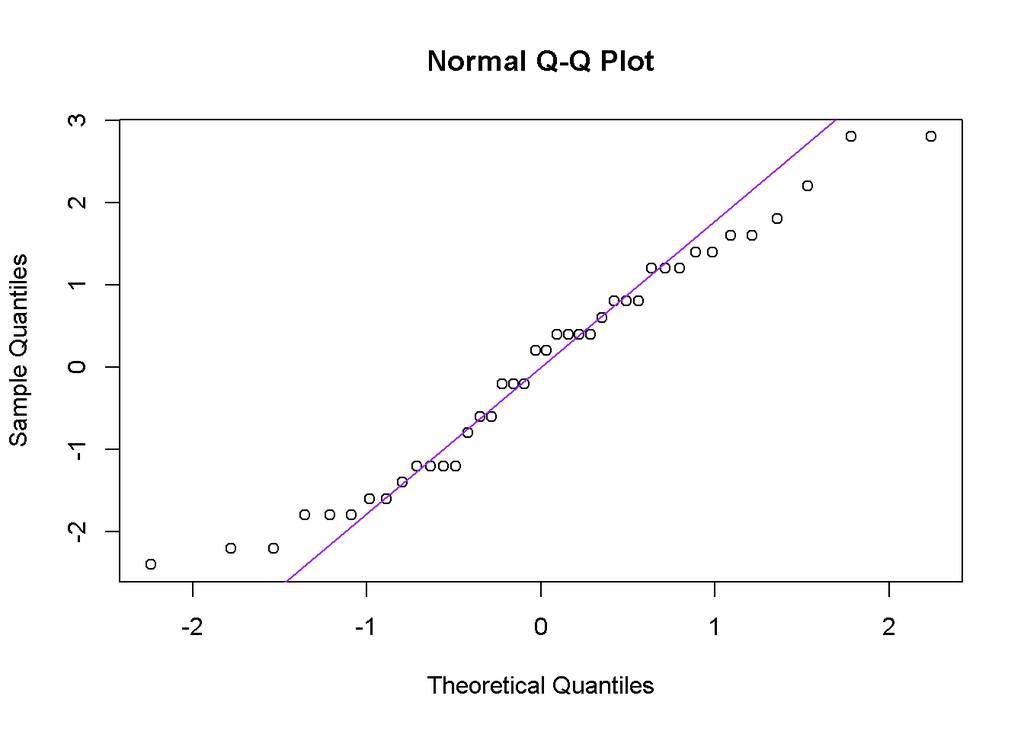

```r
qqnorm(residuals(model_T))
qqline(residuals(model_T), col = "purple")
```

#### Memory

```r
anova_result <- aov(Memory ~ AD_Status * Treatment, data = data)

summary(anova_result)
```

```
##                     Df Sum Sq Mean Sq F value   Pr(>F)
## AD_Status            1 189.22  189.22  75.313 6.45e-10 ***
## Treatment            3  14.48    4.83   1.920    0.146
## AD_Status:Treatment  3   8.67    2.89   1.151    0.344
## Residuals           32  80.40    2.51
## ---
## Signif. codes:  0 '***' 0.001 '**' 0.01 '*' 0.05 '.' 0.1 ' ' 1
```

```r
TukeyHSD(anova_result, "Treatment")
```

```
##   Tukey multiple comparisons of means
##     95% family-wise confidence level
##
## Fit: aov(formula = Memory ~ AD_Status * Treatment, data = data)
##
## $Treatment
##     diff       lwr       upr     p adj
## 2-1  0.3 -1.620592 2.2205916 0.9740962
## 3-1  0.2 -1.720592 2.1205916 0.9920100
## 4-1 -1.2 -3.120592 0.7205916 0.3439678
## 3-2 -0.1 -2.020592 1.8205916 0.9989766
## 4-2 -1.5 -3.420592 0.4205916 0.1697415
## 4-3 -1.4 -3.320592 0.5205916 0.2185144
```

Checking the Anova Results Visually (Memory Performance):

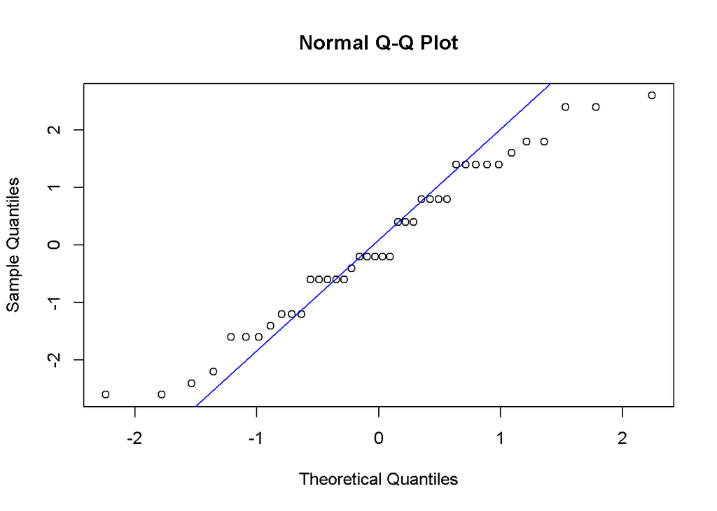

```r
qqnorm(residuals(model_M))
qqline(residuals(model_M), col = "blue")
```

## Discussion

This report examines the effects of different genetic statuses and drug treatments on the training and memory performance of mice used in an Alzheimer’s disease prevention experiment. The study employed a two-way analysis of variance (ANOVA) to explore the influence of two independent variables—genetic status (AD_Status: Transgenic vs. Wild Type) and drug treatment (Drugs 1-4)—on the performance of the mice in a maze task. The dependent variables, training and memory performance, were measured on a continuous scale, with higher scores indicating better performance. The aim was to understand how these genetic and drug treatment factors affect the training and memory outcomes, which could potentially contribute to Alzheimer’s research.